# CLASIFICACION CON SVM Y NN

En la presente actividad se va a emplear un dataset que contiene información de características de celulares para clasificarlos en un rango de precios.

La información del *dataset* es:

- *battery_power*: Energía total que una batería puede almacenar en un tiempo medido en *mAh*
- *blue*: Indica si tiene *bluetooth* o no
- *clock_speed*: Velocidad del microprocesador
- *dual_sim*: Indica si tiene soporte dual de *sim* o no
- *fc*: Megapíxeles de la cámara frontal
- *four_g*: Indica si tiene 4G o no
- *int_memory*: Memoria interna en GB
- *m_dep*: Grosor del celular en cm
- *mobile_wt*: Peso del celular
- *n_cores*: Número de núcleos del procesador
- *pc*: Megapíxeles de la cámara principal
- *px_height*: Alto de la resolución de píxeles
- *px_width*: Ancho de resolución de píxeles
- *ram*: RAM en MB
- *sc_h*: Alto de la pantalla en cm
- *sc_w*: Ancho de la pantalla en cm
- *talk_time*: tiempo máximo que durará una sola carga de la batería
- *tres_g*: Indica si es 3G o no
- *touch_screen*: Indica si tiene pantalla táctil o no
- *wifi*: Indica si tiene wifi o no
- **price_range**: Es la variable objetivo con valor 0 (bajo costo), 1 (costo medio), 2 (costo alto) y 3 (costo muy alto).

# Recomendaciones generales

1. **Establece una semilla aleatoria** para garantizar la reproducibilidad de los resultados (la semilla se definirá más adelante).
2. **Lee el dataset solo una vez**, al inicio del notebook. Evita cargarlo repetidamente.
3. **Usa exclusivamente los hiperparámetros indicados** en cada modelo. Por ejemplo, en el primer SVM utiliza C=1. No modifiques ningún valor a menos que se solicite explícitamente.
4. **Organiza tu notebook** incluyendo celdas para: código, visualizaciones y análisis textual (explicaciones, interpretaciones, etc.).
5. **Responde de manera clara y completa**, siguiendo las instrucciones de cada ejercicio. Cuida tu redacción, ortografía y coherencia.
6. **Ante dudas o ambigüedades**, consulta a través de los canales de comunicación establecidos para resolverlas oportunamente.
7. **Antes de entregar tu actividad**, reinicia el kernel y ejecuta todas las celdas nuevamente para verificar la coherencia de los resultados.

### IMPORTACIÓN DE LIBRERIAS A UTILIZAR

```python
import numpy as np
import pandas as pd

import matplotlib.pyplot as plt
import seaborn as sns

from sklearn.preprocessing import StandardScaler
from sklearn.model_selection import train_test_split, GridSearchCV

from sklearn.svm import SVC
from sklearn.neural_network import MLPClassifier

from sklearn.metrics import accuracy_score, confusion_matrix, classification_report
```

### Definición de semilla

```python
# La semilla que se va a emplear en la presente actividad es 1234, la cual no debes modificar, para garantizar que los resultados que reportes coincidan con los esperados

seed = 1234
```

### CARGA DEL DATASET

```python
data = pd.read_csv('train.csv')
data.head()
```

|  | battery_power | blue | clock_speed | dual_sim | fc | four_g | int_memory | m_dep | mobile_wt | n_cores | ... | px_height | px_width | ram | sc_h | sc_w | talk_time | three_g | touch_screen | wifi | price_range |
| --- | --- | --- | --- | --- | --- | --- | --- | --- | --- | --- | --- | --- | --- | --- | --- | --- | --- | --- | --- | --- | --- |
| 0 | 842 | 0 | 2.2 | 0 | 1 | 0 | 7 | 0.6 | 188 | 2 | ... | 20 | 756 | 2549 | 9 | 7 | 19 | 0 | 0 | 1 | 1 |
| 1 | 1021 | 1 | 0.5 | 1 | 0 | 1 | 53 | 0.7 | 136 | 3 | ... | 905 | 1988 | 2631 | 17 | 3 | 7 | 1 | 1 | 0 | 2 |
| 2 | 563 | 1 | 0.5 | 1 | 2 | 1 | 41 | 0.9 | 145 | 5 | ... | 1263 | 1716 | 2603 | 11 | 2 | 9 | 1 | 1 | 0 | 2 |
| 3 | 615 | 1 | 2.5 | 0 | 0 | 0 | 10 | 0.8 | 131 | 6 | ... | 1216 | 1786 | 2769 | 16 | 8 | 11 | 1 | 0 | 0 | 2 |
| 4 | 1821 | 1 | 1.2 | 0 | 13 | 1 | 44 | 0.6 | 141 | 2 | ... | 1208 | 1212 | 1411 | 8 | 2 | 15 | 1 | 1 | 0 | 1 |

5 rows × 21 columns

```python
#Tamaño del dataset
data.shape
```

```
(2000, 21)
```

```python
#Información de las variables
data.info()
```

```
<class 'pandas.core.frame.DataFrame'>
RangeIndex: 2000 entries, 0 to 1999
Data columns (total 21 columns):
 #   Column         Non-Null Count  Dtype
---  ------         --------------  -----
 0   battery_power  2000 non-null   int64
 1   blue           2000 non-null   int64
 2   clock_speed    2000 non-null   float64
 3   dual_sim       2000 non-null   int64
 4   fc             2000 non-null   int64
 5   four_g         2000 non-null   int64
 6   int_memory     2000 non-null   int64
 7   m_dep          2000 non-null   float64
 8   mobile_wt      2000 non-null   int64
 9   n_cores        2000 non-null   int64
 10  pc             2000 non-null   int64
 11  px_height      2000 non-null   int64
 12  px_width       2000 non-null   int64
 13  ram            2000 non-null   int64
 14  sc_h           2000 non-null   int64
 15  sc_w           2000 non-null   int64
 16  talk_time      2000 non-null   int64
 17  three_g        2000 non-null   int64
 18  touch_screen   2000 non-null   int64
 19  wifi           2000 non-null   int64
 20  price_range    2000 non-null   int64
dtypes: float64(2), int64(19)
memory usage: 328.3 KB
```

# 1. Análisis Exploratorio de Datos (EDA)

## Variables numéricas

```python
# Resumen estadístico de las variables numericas
num_var = ['battery_power', 'clock_speed', 'fc', 'int_memory', 'm_dep', 'mobile_wt', 'n_cores', 'pc', 'px_height', 'px_width', 'ram', 'sc_h', 'sc_w', 'talk_time']
data[num_var].describe()
```

|  | battery_power | clock_speed | fc | int_memory | m_dep | mobile_wt | n_cores | pc | px_height | px_width | ram | sc_h | sc_w | talk_time |
| --- | --- | --- | --- | --- | --- | --- | --- | --- | --- | --- | --- | --- | --- | --- |
| count | 2000.000000 | 2000.000000 | 2000.000000 | 2000.000000 | 2000.000000 | 2000.000000 | 2000.000000 | 2000.000000 | 2000.000000 | 2000.000000 | 2000.000000 | 2000.000000 | 2000.000000 | 2000.000000 |
| mean | 1238.518500 | 1.522250 | 4.309500 | 32.046500 | 0.501750 | 140.249000 | 4.520500 | 9.916500 | 645.108000 | 1251.515500 | 2124.213000 | 12.306500 | 5.767000 | 11.011000 |
| std | 439.418206 | 0.816004 | 4.341444 | 18.145715 | 0.288416 | 35.399655 | 2.287837 | 6.064315 | 443.780811 | 432.199447 | 1084.732044 | 4.213245 | 4.356398 | 5.463955 |
| min | 501.000000 | 0.500000 | 0.000000 | 2.000000 | 0.100000 | 80.000000 | 1.000000 | 0.000000 | 0.000000 | 500.000000 | 256.000000 | 5.000000 | 0.000000 | 2.000000 |
| 25% | 851.750000 | 0.700000 | 1.000000 | 16.000000 | 0.200000 | 109.000000 | 3.000000 | 5.000000 | 282.750000 | 874.750000 | 1207.500000 | 9.000000 | 2.000000 | 6.000000 |
| 50% | 1226.000000 | 1.500000 | 3.000000 | 32.000000 | 0.500000 | 141.000000 | 4.000000 | 10.000000 | 564.000000 | 1247.000000 | 2146.500000 | 12.000000 | 5.000000 | 11.000000 |
| 75% | 1615.250000 | 2.200000 | 7.000000 | 48.000000 | 0.800000 | 170.000000 | 7.000000 | 15.000000 | 947.250000 | 1633.000000 | 3064.500000 | 16.000000 | 9.000000 | 16.000000 |
| max | 1998.000000 | 3.000000 | 19.000000 | 64.000000 | 1.000000 | 200.000000 | 8.000000 | 20.000000 | 1960.000000 | 1998.000000 | 3998.000000 | 19.000000 | 18.000000 | 20.000000 |

### **1.1. Escriba el código que permita crear la matriz de correlación de todas las variables numéricas:**

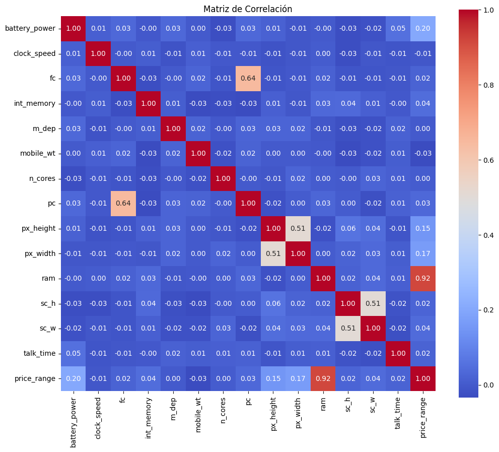

```
Frecuencia de clases en price_range:
price_range
1    0.25
2    0.25
3    0.25
0    0.25
Name: proportion, dtype: float64
```

```python
# Matriz de correlaciones
data_num_df = data[num_var + ['price_range']].copy()
# numericas.remove('price_range')
corr = data_num_df.corr()

# Visualizacion de correlaciones numericas
plt.figure(figsize=(12, 10))
sns.heatmap(corr, annot=True, fmt=".2f", cmap="coolwarm", square=True)
plt.title("Matriz de Correlación")
plt.show()

## Verificar balanceo considerando la variable de respuesta (price_range)
print("\nFrecuencia de clases en price_range:")
print(data_num_df['price_range'].value_counts(normalize=True))  # Proporciones
```

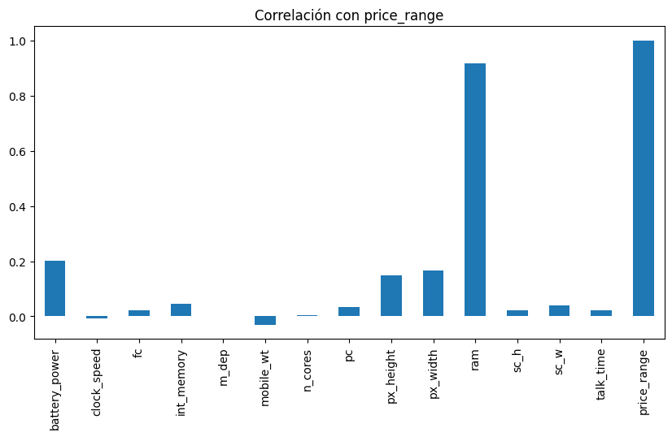

```python
data_num_df.corrwith(data_num_df['price_range']).plot(kind='bar', figsize=(10, 5), title='Correlación con price_range')
```

## Variables catégoricas

### **1.2. Escriba el código para su análisis y la creación de gráficos de frecuencia:**

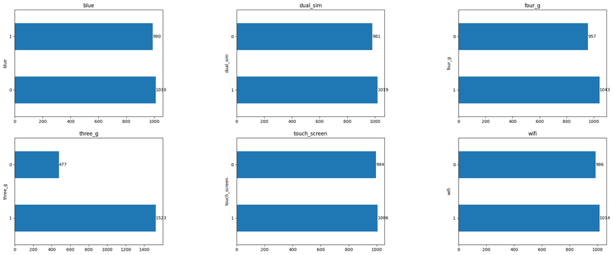

```python
# Resumen variables categóricas
categoricas = ['blue', 'dual_sim', 'four_g', 'three_g', 'touch_screen', 'wifi']

fig,axes = plt.subplots(nrows=2, ncols=3, figsize=(25,10))

plt.subplots_adjust(
    wspace=0.5,
    hspace=0.2
)

for col, ax in zip(data[categoricas], axes.ravel()):
    data[col].value_counts().plot.barh(ax=ax)
    ax.set_title(col)
    ax.bar_label(ax.containers[0])
plt.show()
```

### **1.3. Escriba el código que permita validar si el dataset está balanceado**

```
price_range
1    500
2    500
3    500
0    500
Name: count, dtype: int64
price_range
1    25.0
2    25.0
3    25.0
0    25.0
Name: proportion, dtype: float64
```

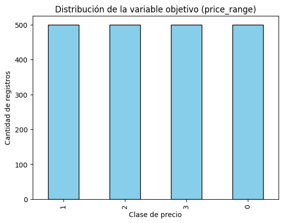

```python
# mostrar la distribucion de price_range
print(data['price_range'].value_counts())

# Ver proporciones
print(data['price_range'].value_counts(normalize=True) * 100)

# Graficar distribución
data['price_range'].value_counts().plot(
    kind='bar',
    color='skyblue',
    edgecolor='black'
)
plt.title("Distribución de la variable objetivo (price_range)")
plt.xlabel("Clase de precio")
plt.ylabel("Cantidad de registros")
plt.show()
```

## PREPROCESAMIENTO DE DATOS

```python
#Crear una copia del dataset para modificaciones
data2 = data.copy()
```

```python
#Verificar tamaño
data2.shape
```

```
(2000, 21)
```

```python
# Separación de los datos en train y test
X = data2.drop(columns = 'price_range')
y = data2['price_range']

X_train, X_test, y_train, y_test = train_test_split(
                                        X,
                                        y,
                                        train_size   = 0.8,
                                        random_state = seed,
                                        shuffle      = True
                                    )
```

### Escriba el código que permita reescalar todos los atributos del dataset utilizando la función del StandardScaler:

```python
# Código para reescalar X_train y X_test mediante StandardScaler
scaler = StandardScaler()
X_train_scaled = scaler.fit_transform(X_train)
X_test_scaled = scaler.transform(X_test)

print(X_train_scaled.mean(axis=0))  # debería ser ~0
```

```
[-2.22044605e-18 -8.88178420e-17 -7.54951657e-17  1.66533454e-18
 -4.21884749e-17  1.13242749e-16 -9.32587341e-17  2.77555756e-18
 -1.95399252e-16 -1.35447209e-16 -1.31006317e-16 -2.22044605e-18
 -1.01030295e-16 -4.55191440e-17 -1.57651669e-16 -3.44169138e-17
  1.23234756e-16  4.44089210e-17  2.22044605e-18  2.22044605e-17]
```

# 2. Aplicación de SVM sobre los datos

⚠️ Importante:

A partir de esta sección, utiliza los datos estandarizados.

### **2.1. Escriba el código que permita crear un modelo utilizando SVM con kernel lineal, el valor de C =1 y random_state=seed**

```python
# Creación del modelo SVM lineal
modeloSVM = SVC(kernel='linear', random_state=seed)
modeloSVM.fit(X_train_scaled, y_train)
```

```
SVC(kernel='linear', random_state=1234)
```

```python
# Predicciones test
predictSVM = modeloSVM.predict(X_test)
predictSVM
```

[output not shown]

### **2.2. Escriba el código que permita hallar la exactitud (accuracy) del modelo SVM anteriormente entrenado:**

```python
predictSVM = modeloSVM.predict(X_test_scaled)
accuracy_svm_base = accuracy_score(y_test, predictSVM)
print(f"Exactitud SVM base: {accuracy_svm_base}")
```

```
Exactitud SVM base: 0.9675
```

### **2.3. Escriba el código que permita encontrar los mejores parámetros para el modelo SVM, con un param_grid = {'C': np.linspace(0.1, 100, 20), 'kernel': ('linear', 'rbf')**

#### Ajuste de hiperparámetros (GridSearchCV)

⚠️ Restricción:

**No imprimas los resultados del GridSearchCV**. Solo utiliza los mejores parámetros encontrados.

```python
# Para que no se impriman los resultados, estos se asignan a _
param_grid = {
    'C': np.linspace(0.1, 100, 20),
    'kernel': ['linear', 'rbf']
    }

grid = GridSearchCV(SVC(random_state=seed), param_grid, cv=5)
_ = grid.fit(X_train_scaled, y_train)
```

### **2.4. Escriba el código que permita conocer los mejores parámetros encontrados en el ítem anterior**

```python
print(f"Mejores parametros: {grid.best_params_}")
```

```
Mejores parametros: {'C': np.float64(36.905263157894744), 'kernel': 'linear'}
```

### **2.5. Escriba el código que permita hallar la exactitud del modelo de SVM aplicando los mejores parámetros**

```python
# Accuracy de test del modelo
# ==============================================================================
best_svm = grid.best_estimator_
predict_best_svm = best_svm.predict(X_test_scaled)
accuracy = accuracy_score(y_test, predict_best_svm)
print(f"Exactitud SVM optimizado: {accuracy}")
```

```
Exactitud SVM optimizado: 0.965
```

### **2.6. Escriba el código que permita hallar la las métricas del modelo entrenado en el ítem anterior. Utilice la función classification_report**

```
              precision    recall  f1-score   support

           0       0.99      0.99      0.99        93
           1       0.96      0.94      0.95       102
           2       0.94      0.94      0.94        98
           3       0.97      0.99      0.98       107

    accuracy                           0.96       400
   macro avg       0.97      0.96      0.96       400
weighted avg       0.96      0.96      0.96       400
```

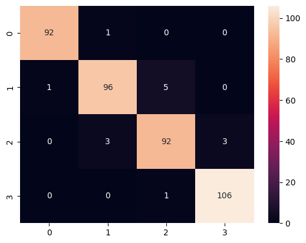

```python
print(classification_report(y_test, predict_best_svm))
# Visualiza matriz de confusión
sns.heatmap(confusion_matrix(y_test, predict_best_svm), annot=True, fmt='d')
plt.show()
```

# 3. REDES NEURONALES

⚠️ Recordatorio:

- Mantén los datos normalizados (los mismos que usaste en SVM).
- No regreses al dataset original ni repitas pasos anteriores, a menos que se indique explícitamente.

### **3.1. Escriba el código que permita entrenar un perceptrón multicapa con 3 capas ocultas con 200, 100 y 50 neuronas respectivamente en cada capa. Función de activación 'Relu' y random_state=seed**

```python
classifier = MLPClassifier(hidden_layer_sizes=(200, 100, 50), activation='relu', random_state=seed, max_iter=1000)
classifier.fit(X_train_scaled, y_train)
```

```
MLPClassifier(hidden_layer_sizes=(200, 100, 50), max_iter=1000,
              random_state=1234)
```

### **3.2. Escriba el código que permita hallar la exactitud del modelo de redes neuronales anteriormente entrenado:**

```python
predict_nn = classifier.predict(X_test_scaled)
accuracy_nn = accuracy_score(y_test, predict_nn)
print(f"Exactitud NN: {accuracy_nn}")
```

```
Exactitud NN: 0.925
```

### **3.3. Escriba el código que permita hallar la las métricas del modelo entrenado en el ítem anterior. Utilice la función classification_report**

```python
print(classification_report(y_test, predict_nn))
```

```
              precision    recall  f1-score   support

           0       0.94      0.96      0.95        93
           1       0.93      0.85      0.89       102
           2       0.87      0.94      0.90        98
           3       0.97      0.95      0.96       107

    accuracy                           0.93       400
   macro avg       0.93      0.93      0.92       400
weighted avg       0.93      0.93      0.92       400
```

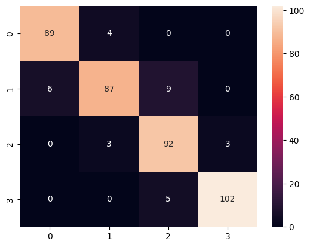

```python
# Matriz de confusión
sns.heatmap(confusion_matrix(y_test, predict_nn), annot=True, fmt='d')
plt.show()
```

### 4. **Conclusiones**

Escribe tus conclusiones finales, reflexionando sobre los resultados obtenidos con SVM y MLP. Compara los siguientes aspectos:

1. Métricas relevantes:
- ¿Cuáles métricas fueron clave para evaluar el desempeño?
2. Fortalezas y limitaciones:
- Ventajas y desventajas de cada modelo en este caso específico.

### 1. ¿Cuáles métricas fueron clave para evaluar el desempeño?

Para realzar el análisis del desempeño de ambos modelos fue necesario enfocarnos en el `classification_report` para evaluar cambios que puedan dar un cambio aunque mínimo, que tienda a resultar con mejor exactitud.

#### Reporte de *Support Vector Machine*

[figure not shown]

El reporte de clasificación nos arroja muy buenos resultados, en general el modelo clasifica muy bien cada una de las 4 clases teniendo pocas predicciones que caen en falsos positivos y falsos negativos.

Este modelo llega a una exactitud del **96% (0.96)** el cual es un excelente modelo en general para realizar la clasificacion de las clases

#### Reporte de *Neuronal Network*

[figure not shown]

Para este segundo modelo que se realizo utilizando *Neuronal Network* el `classification_report` arrojó el siguiente resultado.

El modelo presenta buenas métricas, teniendo una exactitud del **93% (0.93)**, sin embargo, al comparar los resultados tiene valores inferiores al modelo de *SVM* específicamente en las **Clases 1 y 2** donde el valor de Recall es **0.85** y valor **0.89** en F1-Score para la clase 1.

#### Conclusión

Las méticas relevantes que permiten evaluar que modelo es el ideal en estos dos casos específicos recayeron sobre el valor de **Precision**, **Recall**, **F1-Score** y **Accuracy**.

### 2. Ventajas y desventajas de cada modelo

#### *Support Vector Machine*

Ventajas:

- **Precision y Rendimiento:** Al tener una exxactitud del **96%** la clasificación en cada una de las clases es alta si vamos a detalle en la tabla de `classification_report` mostrada anteriormente, esto nos demuestra un modelo robusto y muy buen balance en cada una de las clases.
- **Eficiencia en datos:** El utilizar *SVM* es muy efectivo con problemas de clasificación donde hay un gran número de muestras o cuando los datos son linealmente separables en un espacio.

Desventajas:

- **Elección del Kernel:** El rendimiento que pueda tener el *SVM* depende en gran medida de la elección correcta del *Kernel* y los parámetros del modelo. Una mala configuración de los parametros o el *kernel* puede dar como resultado un modelo deficiente.
- **Lento en *datasets* grandes:** Este modelo no tiene un buen rendimiento cuando la cantidad de datos es muy grande, por lo que el tiempo de entrenamiento para un *SVM* puede volverse computacionalmente costoso.

#### *Neuronal Network*

Ventajas:

- **Aprendizaje de Patrones Complejos:** Este modelo funciona muy bien para aprender patrones complejos donde tiene que crear relaciones no lineales complejas entre las características de entrada y la salida. En este escenario donde el dataset idealmente son clasificaciones lineales el modelo puede llegar a configurarse para poder tener un rendimiento similar al del SVM
- **Escalabilidad:** A diferencia de un modelo de *SVM* este modelo de *NN* tiene mejor rendimiento con *datasets* que son grandes. Esto hace que un modelo de *NN* sea la mejor opción cuando nuestro conjunto de datos de entrenamiento es grande y no necesariamente sea de clasificación lineal.

Desventajas:

- **Precision:** En esta actividad de clasificación concretamente no tuvo un buen desempeño especialmente en la clase 1 y 2 como se menciono anteriormente.
- **Datos requeridos:** Este modelo por lo general requieren de un volumen considerable de datos de entrenamiento para evitar caer en *overfitting*. Además que el ajustar un modelo de *NN* es más complejo ya que requiere ajustar hiperparámetros como *número de capas, neuronas, funciones de activación, tasa de aprendizaje, etc.*